# Part II - Prosper Loan Data Exploration

## by Solomon Nyamson

## Investigation Overview

The analysis will begin by looking into the factors for the interest rate and annual percentage rate of the borrowers, respectively.

What distinguishes the borrower rate from the borrower APR, and what accounts for the differences between the two.

## Dataset Overview

This project explores the Proper loan dataset, which is America’s first marketplace lending platform, with over $9 billion in funded loans. This data set contains 113,937 loans with 81 variables on each loan, including loan amount, borrower rate (or interest rate), current loan status, borrower income, borrower employment status, borrower credit history, and the latest payment information.

## The Distribution of Borrowers Interest Rate and Borrowers APR

The Borrower's Rate (interest rate) refers to the annual cost of a loan to a borrower and is expressed as a percentage. The interest rate does not include fees charged for the loan.

The Borrower's APR is the annual cost of a loan to a borrower. Unlike an interest rate, it includes other charges or fees (such as mortgage insurance, most closing costs, discount points and loan origination fees) to reflect the total cost of the loan.

The Borrowers APR is always expected to be higher than the Borrowers Rate which does not include any fees charged for the loan in question and this implies that the distribution for both variable should be similar with a subtle difference.

From the plots, there are two peaks centered at 0.2 and 0.28, respectively, and a very shaped peak between 0.35 and 0.36. A very small number of loans have an APR higher than 0.4.

Plotting the two distributions on one another, it can be affirmed that, the interest rate retains the same multi-modal distribution with slightly lower values.

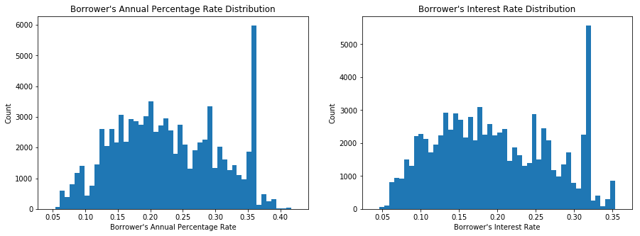

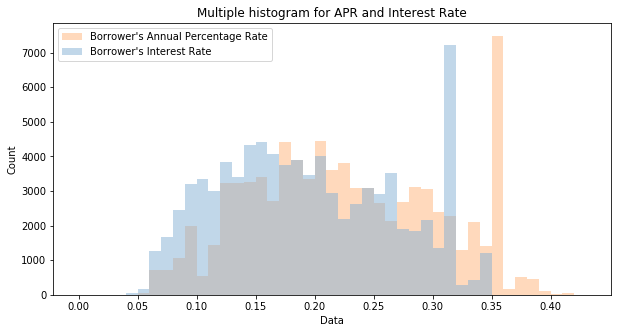

## How does the Estimated Return relates to the Borrower Rate of a loan and Prosper Rating

This plot shows a clear pattern between the three variables. The estimated return definitely has a positive linear relationship with the borrower's interest rate and Prosper rating.

This implies that, the borrower rate of a loan will increase if the underlying prosper rating increase so as the estimated return associated with the loan.

Loans that fall under Ratings E and HR are highly associated with high borrower rate indicating the risk level of such loans.

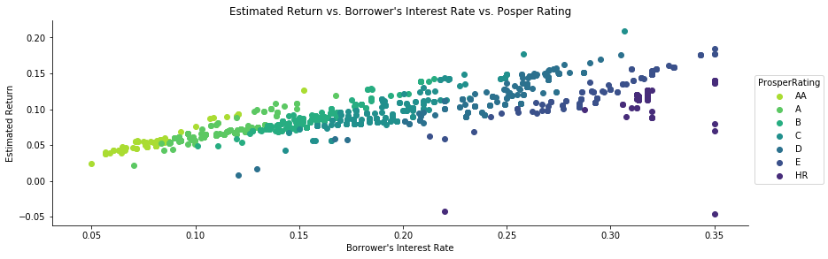

## How does the Stated Monthly Income reacts with the Monthly Loan Payment

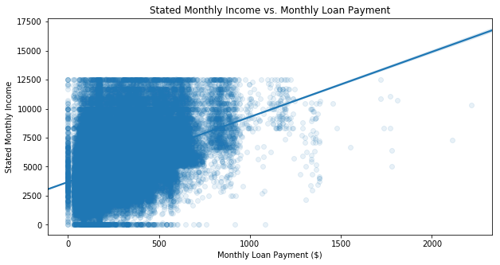